# RepData PeerAssesssment 1

## Imputing missing values

- Number of rows in dataset with missing values

```r
sum(is.na(fitdata))
```

```
## [1] 2304
```

- Strategy: Use the mean for that 5-minute interval to fill in missing values (utilizing below function)

```r
meanIntervalSteps<-function(interval){
  stepsInterval[stepsInterval$interval==interval,]$steps
}
```

- Create a copy of the original data and fill NA rows with chosen strategy:

```r
fitdataComplete<-fitdata
for(i in 1:nrow(fitdataComplete)){
  if(is.na(fitdataComplete[i,]$steps)){
    fitdataComplete[i,]$steps<-meanIntervalSteps(fitdataComplete[i,]$interval)
  }
}
```

- Process complete data: steps~date

```r
totalStepsComplete <- aggregate(steps~date, data=fitdataComplete, sum, na.rm=TRUE)
```

- Mean of the total number of steps taken per day without missing values

```r
mean(totalStepsComplete$steps, na.rm = TRUE)
```

```
## [1] 10766.19
```

- Median of the total number of steps taken per day

```r
median(totalStepsComplete$steps, na.rm = TRUE)
```

```
## [1] 10766.19
```

- Basically the values are the same (not identical)
- The **mean** value is the **identical** as the value before imputing missing data.
- The median value shows **a little** difference.

## Are there differences in activity patterns between weekdays and weekends?

```r
fitdataComplete$date <- as.Date(fitdataComplete$date)

weekDay.End <- function(date) {
  day <- weekdays(date)
  if (day %in% c("Monday", "Tuesday", "Wednesday", "Thursday", "Friday"))
    return("weekday")
  else if (day %in% c("Saturday", "Sunday"))
    return("weekend")
  else
    stop("invalid date")
}
```

- Create new factor variable weekday/weekend

```r
fitdataComplete$day <- sapply(fitdataComplete$date, FUN=weekDay.End)
totalStepsWeekDay.End <- aggregate(steps ~ interval + day, data=fitdataComplete, mean)
```

- Panel plot weekday/weekend

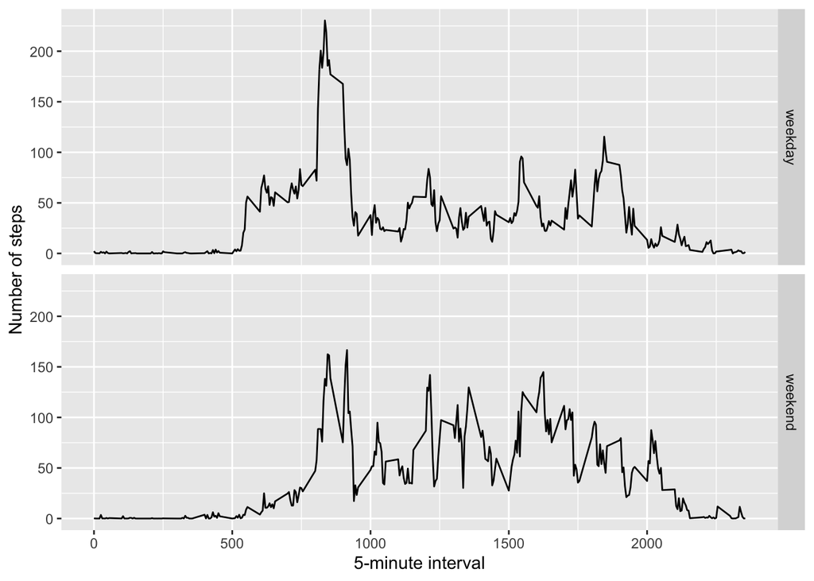

```r
library(ggplot2)

ggplot(totalStepsWeekDay.End, aes(interval, steps)) + geom_line() + facet_grid(day ~ .) +
  xlab("5-minute interval") + ylab("Number of steps")
```